# Recurrencia de Carcinoma Renal tras el Tratamiento

Rafa Carretero

2024-11-13

### Tabla 1. Características generales de la cohorte de estudio

**Tabla 1. Características generales de la cohorte de estudio**

| **Variable** | **N = 110**<sup>1</sup> |
| --- | --- |
| Sexo |  |
| Hombre | 74 (67%) |
| Mujer | 36 (33%) |
| Edad | 63 (56, 69) |
| Grupo pronóstico |  |
| Bueno | 52 (47%) |
| Intermedio | 56 (51%) |
| Malo | 2 (1.8%) |
| Tratamiento Primera Línea |  |
| Pazopanib | 7 (6.4%) |
| Sorafenib | 1 (0.9%) |
| Sunitinib | 101 (92%) |
| Sunitinib/Everolimus | 1 (0.9%) |
| Respuesta tras Primer Tratamiento |  |
| No | 8 (7.3%) |
| Sí | 102 (93%) |
| Tipo Histológico |  |
| Ca. células claras | 89 (81%) |
| Otro | 21 (19%) |
| Nefrectomía |  |
| No | 2 (1.8%) |
| Si | 108 (98%) |
| Recivida |  |
| No | 37 (34%) |
| Sí | 73 (66%) |
| Tiempo Libre de Enfermedad | 475 (253, 908) |
| Tiempo de Supervivencia Global | 758 (532, 1,200) |
| Fallecimiento |  |
| No | 63 (57%) |
| Probable | 3 (2.7%) |
| Si | 44 (40%) |

<sup>1</sup> Medidas expresadas en Mediana (RIQ) o Frecuencia (%)

### Tabla 2. Características generales de la cohorte (respecto a la progresión de la enfermedad)

**Tabla 2. Características generales de la cohorte de estudio**

| **Variable** | **Overall**, N = 110<sup>1</sup> | **Progresión de la Enfermedad** **No**, N = 37<sup>1</sup> | **Progresión de la Enfermedad** **Sí**, N = 73<sup>1</sup> |
| --- | --- | --- | --- |
| Sexo |  |  |  |
| Hombre | 74 (67%) | 20 (54%) | 54 (74%) |
| Mujer | 36 (33%) | 17 (46%) | 19 (26%) |
| Edad | 63 (56, 69) | 61 (56, 65) | 63 (57, 70) |
| Grupo pronóstico |  |  |  |
| Bueno | 52 (47%) | 23 (62%) | 29 (40%) |
| Intermedio | 56 (51%) | 13 (35%) | 43 (59%) |
| Malo | 2 (1.8%) | 1 (2.7%) | 1 (1.4%) |
| Tratamiento Primera Línea |  |  |  |
| Pazopanib | 7 (6.4%) | 3 (8.1%) | 4 (5.5%) |
| Sorafenib | 1 (0.9%) | 0 (0%) | 1 (1.4%) |
| Sunitinib | 101 (92%) | 33 (89%) | 68 (93%) |
| Sunitinib/Everolimus | 1 (0.9%) | 1 (2.7%) | 0 (0%) |
| Respuesta tras Primer Tratamiento |  |  |  |
| No | 8 (7.3%) | 1 (2.7%) | 7 (9.6%) |
| Sí | 102 (93%) | 36 (97%) | 66 (90%) |
| Tipo Histológico |  |  |  |
| Ca. células claras | 89 (81%) | 32 (86%) | 57 (78%) |
| Otro | 21 (19%) | 5 (14%) | 16 (22%) |
| Nefrectomía |  |  |  |
| No | 2 (1.8%) | 1 (2.7%) | 1 (1.4%) |
| Si | 108 (98%) | 36 (97%) | 72 (99%) |
| Tiempo Libre de Enfermedad | 475 (253, 908) | 735 (454, 1,147) | 378 (241, 688) |
| Tiempo de Supervivencia Global | 758 (532, 1,200) | 911 (594, 1,253) | 725 (502, 1,149) |
| Fallecimiento |  |  |  |
| No | 63 (57%) | 34 (92%) | 29 (40%) |
| Probable | 3 (2.7%) | 1 (2.7%) | 2 (2.7%) |
| Si | 44 (40%) | 2 (5.4%) | 42 (58%) |

<sup>1</sup> Medidas expresadas en Mediana (RIQ) o Frecuencia (%)

### Figura 1. Análisis exploratorio del gen AXL (distribución)

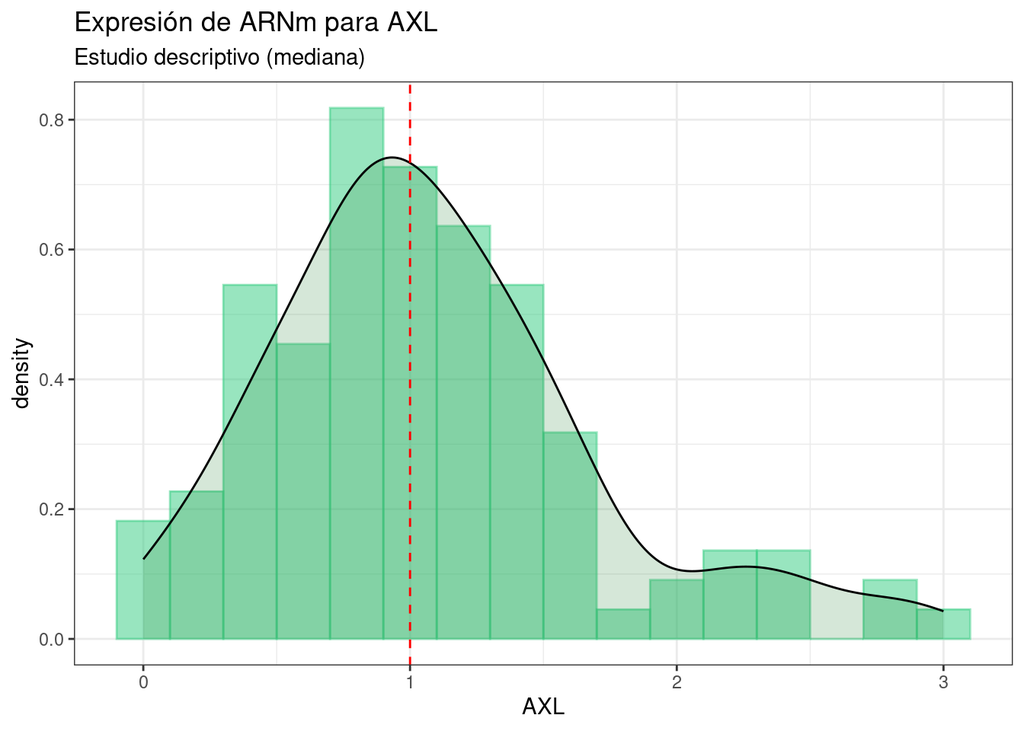

### Figura 2. Análisis exploratorio del gen AXL (bloxplot)

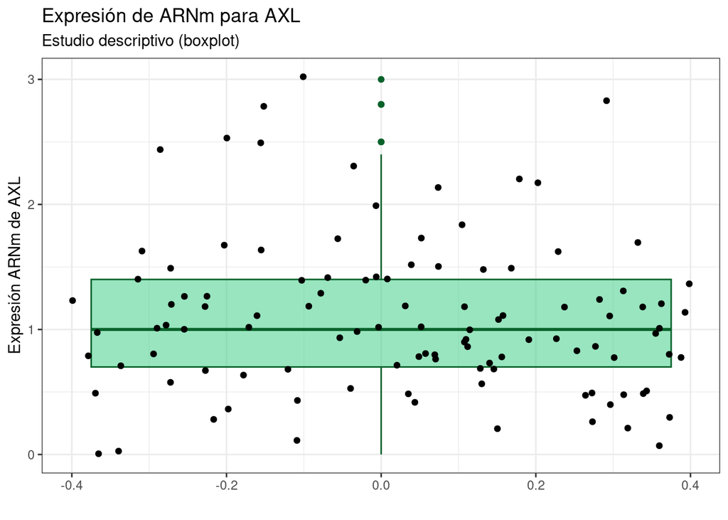

### Figura 3. Análisis exploratorio del gen BAP1 (distribución)

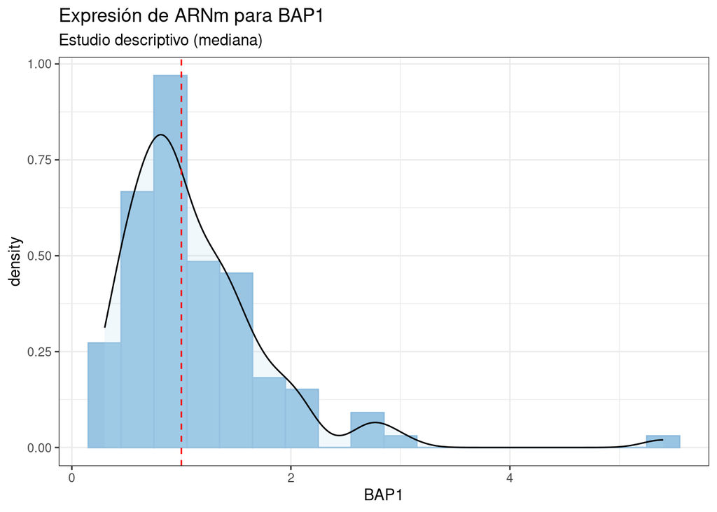

### Figura 4. Análisis exploratorio del gen BAP1 (bloxplot)

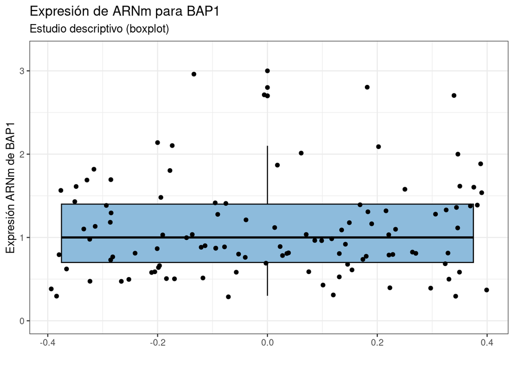

### Figura 5. Análisis exploratorio del gen CA9 (distribución)

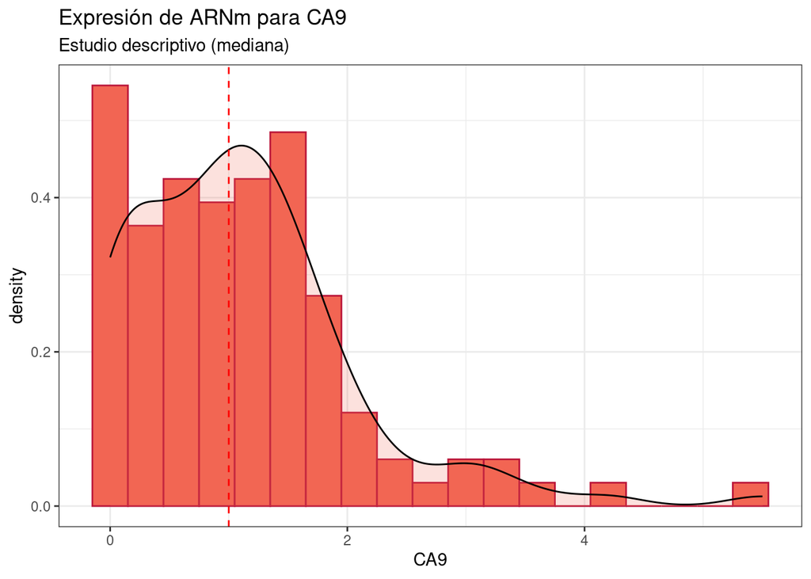

### Figura 6. Análisis exploratorio del gen CA9 (bloxplot)

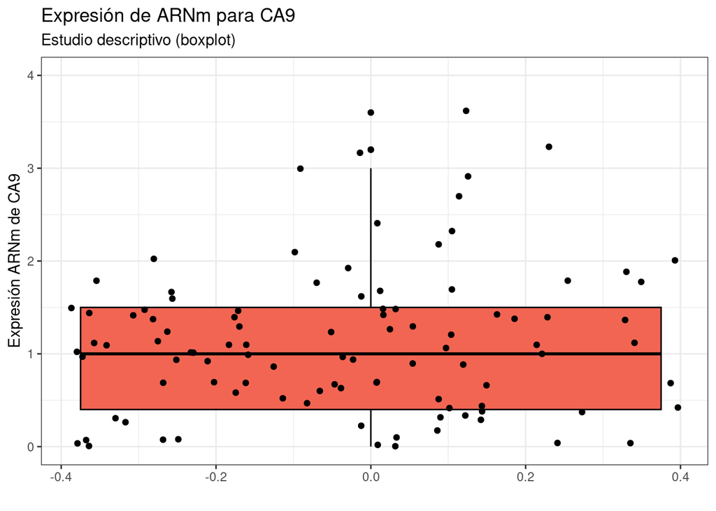

### Tabla 3. Características generales de la cohorte (respecto a la progresión de la enfermedad)

Ya que hemos categorizado la expresión de los genes AXL, BAP1 y CA9 respecto a la mediana (en los tres casos es 1), podemos hacer dos grupos con cada gen: **los que expresan** (por encima de la mediana) y **los que no expresan** (por debajo de la mediana).

En la siguiente tabla realizamos el primer estudio bivariado (**correlacional**) con los test de *Chi cuadrado* o *Wilcoxon*, según esté indicado.

**Tabla 3. Características generales de la cohorte de estudio (con expresión ARNm)**

| **Variable** | **Overall**, N = 110<sup>1</sup> | **Progresión de la Enfermedad** **No**, N = 37<sup>1</sup> | **Progresión de la Enfermedad** **Sí**, N = 73<sup>1</sup> | **p-value**<sup>2</sup> |  |
| --- | --- | --- | --- | --- | --- |
| Sexo |  |  |  |  | 0.035 |
| Hombre | 74 (67%) | 20 (54%) | 54 (74%) |  |  |
| Mujer | 36 (33%) | 17 (46%) | 19 (26%) |  |  |
| Edad | 63 (56, 69) | 61 (56, 65) | 63 (57, 70) | 0.21 |  |
| Grupo pronóstico |  |  |  | 0.034 |  |
| Bueno | 52 (47%) | 23 (62%) | 29 (40%) |  |  |
| Intermedio | 56 (51%) | 13 (35%) | 43 (59%) |  |  |
| Malo | 2 (1.8%) | 1 (2.7%) | 1 (1.4%) |  |  |
| Tratamiento Primera Línea |  |  |  | 0.52 |  |
| Pazopanib | 7 (6.4%) | 3 (8.1%) | 4 (5.5%) |  |  |
| Sorafenib | 1 (0.9%) | 0 (0%) | 1 (1.4%) |  |  |
| Sunitinib | 101 (92%) | 33 (89%) | 68 (93%) |  |  |
| Sunitinib/Everolimus | 1 (0.9%) | 1 (2.7%) | 0 (0%) |  |  |
| Respuesta tras Primer Tratamiento |  |  |  | 0.26 |  |
| No | 8 (7.3%) | 1 (2.7%) | 7 (9.6%) |  |  |
| Sí | 102 (93%) | 36 (97%) | 66 (90%) |  |  |
| Tipo Histológico |  |  |  | 0.29 |  |
| Ca. células claras | 89 (81%) | 32 (86%) | 57 (78%) |  |  |
| Otro | 21 (19%) | 5 (14%) | 16 (22%) |  |  |
| Expresión AXL |  |  |  | 0.20 |  |
| <Mediana | 60 (55%) | 17 (46%) | 43 (59%) |  |  |
| >Mediana | 50 (45%) | 20 (54%) | 30 (41%) |  |  |
| Expresión BAP1 |  |  |  | 0.74 |  |
| <Mediana | 63 (57%) | 22 (59%) | 41 (56%) |  |  |
| >Mediana | 47 (43%) | 15 (41%) | 32 (44%) |  |  |
| Expresión CA9 |  |  |  | 0.38 |  |
| <Mediana | 57 (52%) | 17 (46%) | 40 (55%) |  |  |
| >Mediana | 53 (48%) | 20 (54%) | 33 (45%) |  |  |
| Nefrectomía |  |  |  | >0.99 |  |
| No | 2 (1.8%) | 1 (2.7%) | 1 (1.4%) |  |  |
| Si | 108 (98%) | 36 (97%) | 72 (99%) |  |  |
| Tiempo Libre de Enfermedad | 475 (253, 908) | 735 (454, 1,147) | 378 (241, 688) | 0.006 |  |
| Tiempo de Supervivencia Global | 758 (532, 1,200) | 911 (594, 1,253) | 725 (502, 1,149) | 0.16 |  |
| Fallecimiento |  |  |  | <0.001 |  |
| No | 63 (57%) | 34 (92%) | 29 (40%) |  |  |
| Probable | 3 (2.7%) | 1 (2.7%) | 2 (2.7%) |  |  |
| Si | 44 (40%) | 2 (5.4%) | 42 (58%) |  |  |

<sup>1</sup> Medidas expresadas en Mediana (RIQ) o Frecuencia (%)  
<sup>2</sup> Pearson’s Chi-squared test; Wilcoxon rank sum test; Fisher’s exact test

## Regresión logística para la recaída (I)

**Tabla 4. Análisis multivariado con regresión logística**

| **Variable** | **OR**<sup>1</sup> | **95% CI**<sup>1</sup> | **p-value** |
| --- | --- | --- | --- |
| Sexo |  |  |  |
| Mujer | — | — |  |
| Hombre | 4.82 | 1.75, 14.6 | 0.003 |
| Edad | 1.03 | 0.99, 1.08 | 0.2 |
| Grupo pronóstico |  |  |  |
| Bueno | — | — |  |
| Intermedio/Malo | 4.32 | 1.62, 12.8 | 0.005 |
| Tratamiento Primera Línea |  |  |  |
| Pazopanib | — | — |  |
| Sorafenib | 77,836,228 | 0.00, NA | >0.9 |
| Sunitinib | 1.39 | 0.19, 9.47 | 0.7 |
| Sunitinib/Everolimus | 0.00 |  | >0.9 |
| Respuesta tras Primer Tratamiento |  |  |  |
| No | — | — |  |
| Sí | 0.51 | 0.02, 3.71 | 0.6 |
| Tipo Histológico |  |  |  |
| Ca. células claras | — | — |  |
| Otro | 0.87 | 0.24, 3.54 | 0.8 |
| AXL_cat |  |  |  |
| <Mediana | — | — |  |
| >Mediana | 0.28 | 0.09, 0.81 | 0.023 |
| BAP1_cat |  |  |  |
| <Mediana | — | — |  |
| >Mediana | 2.53 | 0.90, 7.83 | 0.091 |
| CA9_cat |  |  |  |
| <Mediana | — | — |  |
| >Mediana | 1.01 | 0.39, 2.65 | >0.9 |
| Nefrectomía |  |  |  |
| No | — | — |  |
| Si | 3.27 | 0.10, 105 | 0.5 |

<sup>1</sup> OR = Odds Ratio, CI = Confidence Interval

## Regresión logística para la recaída (reduciendo predictores, vía *stepwise*)

*Stepwise* es una técnica de *machine learning* que reduce el número de predictores a los mínimos necesarios para que el modelo tenga menos variables. La siguiente tabla muestra resultados similares a la previa, pero con menos predictores. La alta expresión de AXL sigue siendo un *aparente* factor de protección frente a la recaída.

**Tabla 5. Análisis multivariado con regresión logística (stepwise)**

| **Variable** | **OR**<sup>1</sup> | **95% CI**<sup>1</sup> | **p-value** |
| --- | --- | --- | --- |
| Sexo |  |  |  |
| Mujer | — | — |  |
| Hombre | 4.68 | 1.76, 13.6 | 0.003 |
| Grupo pronóstico |  |  |  |
| Bueno | — | — |  |
| Intermedio/Malo | 3.92 | 1.57, 10.6 | 0.005 |
| Tratamiento Primera Línea |  |  |  |
| Pazopanib | — | — |  |
| Sorafenib | 43,912,132 | 0.00, NA | >0.9 |
| Sunitinib | 1.38 | 0.21, 8.26 | 0.7 |
| Sunitinib/Everolimus | 0.00 |  | >0.9 |
| AXL_cat |  |  |  |
| <Mediana | — | — |  |
| >Mediana | 0.30 | 0.10, 0.81 | 0.022 |
| BAP1_cat |  |  |  |
| <Mediana | — | — |  |
| >Mediana | 2.40 | 0.87, 7.21 | 0.10 |

<sup>1</sup> OR = Odds Ratio, CI = Confidence Interval

## Análisis de supervivencia

Analizamos ahora el tiempo libre de enfermedad (tiempo hasta la progresión) de manera global, primero, y categorizada a la expresión de los genes de interés, después.

### Curva de Kaplan-Meier global (I)

Con el primer estimador calculamos la el tiempo libre de enfermedad de toda la cohorte. Usamos sólo el tiempo y la recaída.

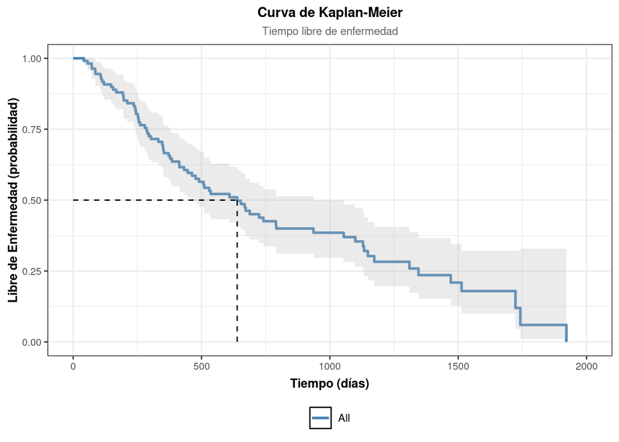

```
## Call: survfit(formula = Surv(PFS_1erTKI_days, PE_1erTKI_0No_1Si) ~
##     1, data = pacientes)
##
##        n events median 0.95LCL 0.95UCL
## [1,] 110     73    639     463     936
```

|  | **Mediana de Surpervivencia** |
| --- | --- |
| Overall | 639 (463, 936) |

### Curva de Kaplan-Meier AXL (II)

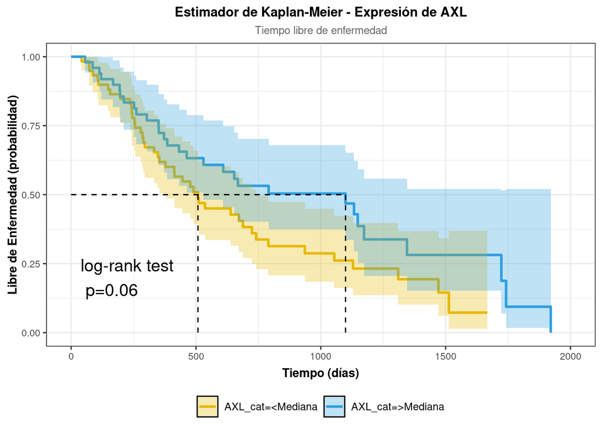

```
## Call: survfit(formula = Surv(PFS_1erTKI_days, PE_1erTKI_0No_1Si) ~
##     AXL_cat, data = pacientes)
##
##                   n events median 0.95LCL 0.95UCL
## AXL_cat=<Mediana 60     43    508     378     741
## AXL_cat=>Mediana 50     30   1099     530      NA
```

| **Supervivencia** | **Mediana de Surpervivencia** |
| --- | --- |
| AXL_cat |  |
| <Mediana | 508 (378, 741) |
| >Mediana | 1,099 (530, —) |

### Curva de Kaplan-Meier BAP1 (III)

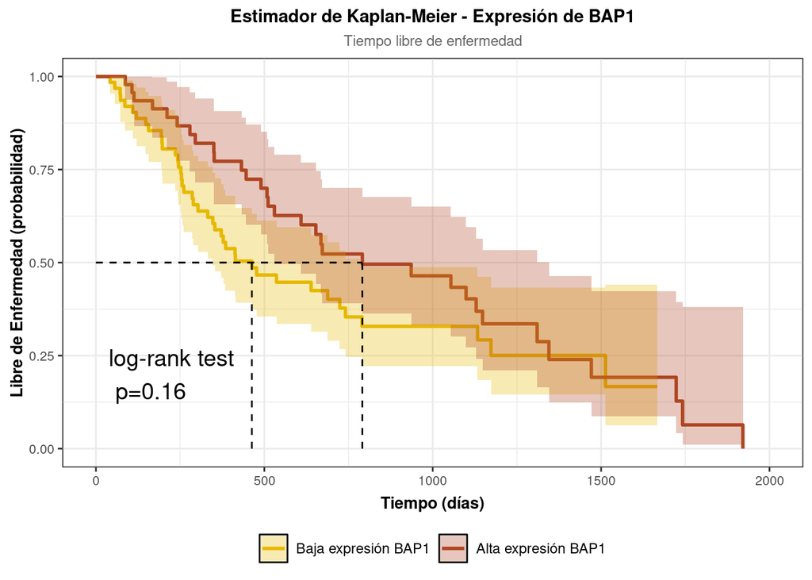

### Curva de Kaplan-Meier CA9 (IV)

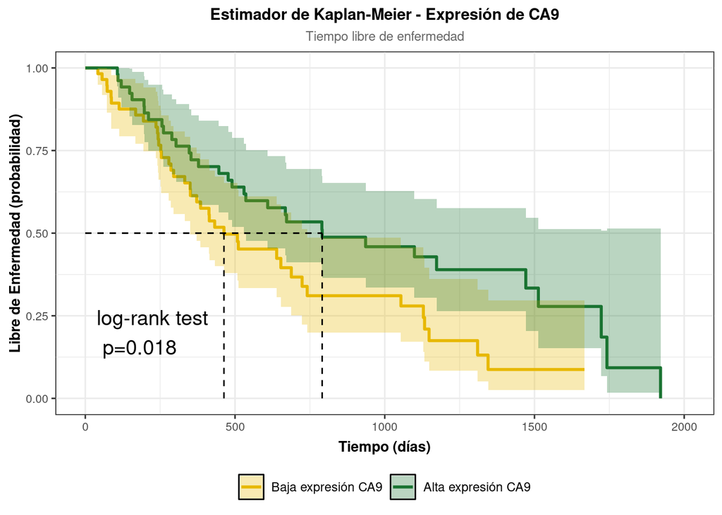

### Curva de Kaplan-Meier - Respuesta al tratamiento (V)

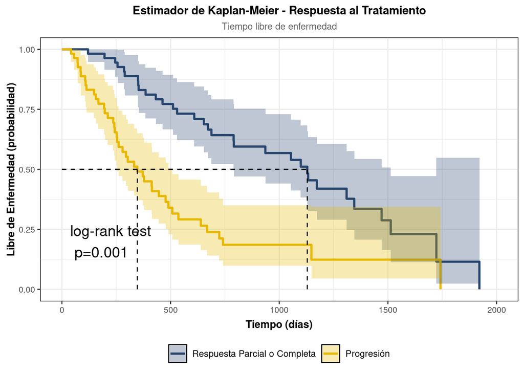

## Regresión de Cox

**Tabla 6. Hazard Ratios Ajustados**

| **Variable** | **HR**<sup>1</sup> | **95% CI**<sup>1</sup> | **p-value** |
| --- | --- | --- | --- |
| Mejor_Respuesta |  |  |  |
| No | — | — |  |
| Sí | 0.02 | 0.01, 0.09 | <0.001 |
| AXL_cat |  |  |  |
| <Mediana | — | — |  |
| >Mediana | 0.87 | 0.51, 1.48 | 0.6 |
| BAP1_cat |  |  |  |
| <Mediana | — | — |  |
| >Mediana | 0.85 | 0.51, 1.40 | 0.5 |
| CA9_cat |  |  |  |
| <Mediana | — | — |  |
| >Mediana | 0.59 | 0.36, 0.97 | 0.037 |

<sup>1</sup> HR = Hazard Ratio, CI = Confidence Interval